# Phenotypic selection models

Francisco E. Fonturbel

5/October/2020

## Testing new approaches to estimate phenotypic selection in wild plant populations

This file contains the code to reproduce the statistical analyses presented in the paper.

## Correlation among traits

First, we will examine the correlation among traits measured (based on their standardized values):

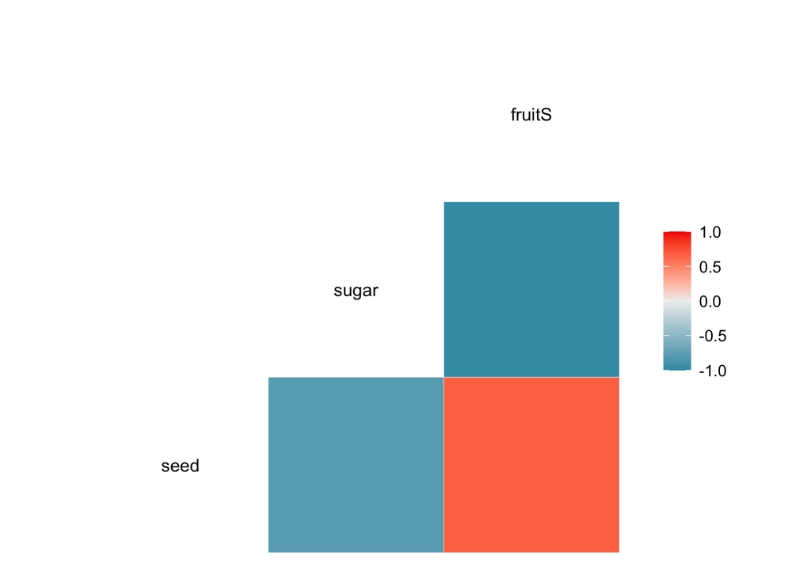

As we can see here, those fruit traits present an important correlation, which makes sense from the biological point of view.

### Trait relationships with fitness (w)

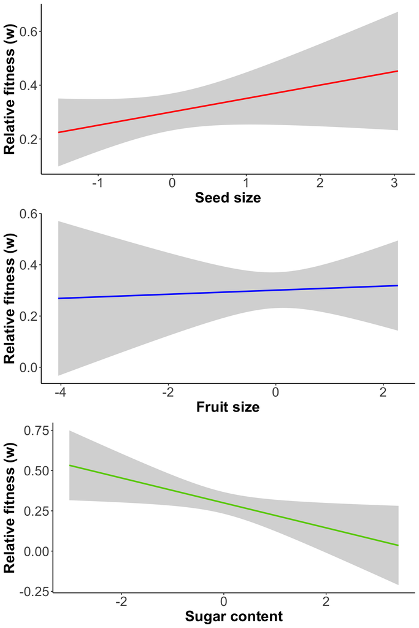

## Multidimensional Scaling

Now we will conduct a Multidimensional Scaling (MDS) Analysis (after Gower,1966) to summarize relatedness data in two dimensions.

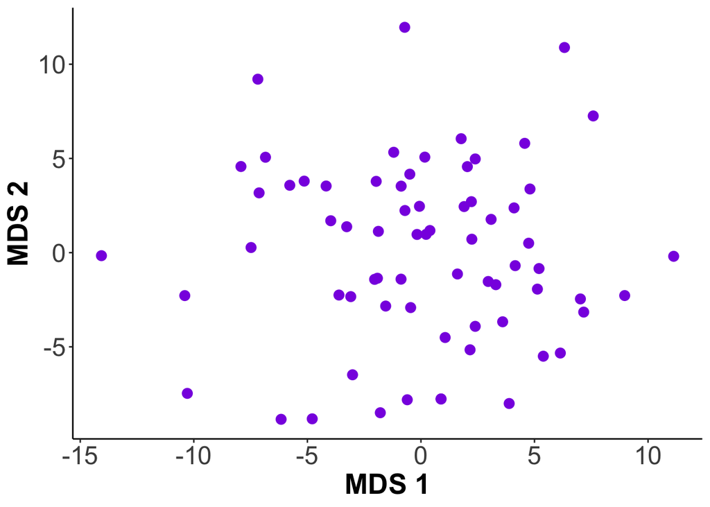

This MDS vector will be used in further analyses to take the genetic component into account.

# Models

## GAM models

The first approach that we will try is based on Generalized Additive Models `gam` that include the elements of Lande & Arnold’s equation plus two splines: one to take the space into account and the other to take the inter-individual relatedness into account.

**Classic model**

```
##
## Family: gaussian
## Link function: identity
##
## Formula:
## w ~ fruitS + seedS + sugarS
##
## Parametric coefficients:
##             Estimate Std. Error t value Pr(>|t|)
## (Intercept)  0.30025    0.03365   8.923 6.77e-13 ***
## fruitS      -0.06122    0.04441  -1.378  0.17283
## seedS        0.09570    0.04305   2.223  0.02969 *
## sugarS      -0.09460    0.03541  -2.672  0.00953 **
## ---
## Signif. codes:  0 '***' 0.001 '**' 0.01 '*' 0.05 '.' 0.1 ' ' 1
##
##
## R-sq.(adj) =  0.0934   Deviance explained = 13.3%
## GCV = 0.082796  Scale est. = 0.077996  n = 69
```

**Spatial model**

```
##
## Family: gaussian
## Link function: identity
##
## Formula:
## w ~ fruitS + seedS + sugarS + s(x, y, k = 10)
##
## Parametric coefficients:
##             Estimate Std. Error t value Pr(>|t|)
## (Intercept)  0.29826    0.02352  12.681  < 2e-16 ***
## fruitS       0.01597    0.03435   0.465  0.64370
## seedS        0.08188    0.03405   2.405  0.01938 *
## sugarS      -0.08347    0.02651  -3.148  0.00259 **
## ---
## Signif. codes:  0 '***' 0.001 '**' 0.01 '*' 0.05 '.' 0.1 ' ' 1
##
## Approximate significance of smooth terms:
##          edf Ref.df     F  p-value
## s(x,y) 6.839  8.077 8.456 4.63e-07 ***
## ---
## Signif. codes:  0 '***' 0.001 '**' 0.01 '*' 0.05 '.' 0.1 ' ' 1
##
## R-sq.(adj) =  0.557   Deviance explained = 62.1%
## GCV = 0.045195  Scale est. = 0.038095  n = 69
```

**Genetic model**

```
##
## Family: gaussian
## Link function: identity
##
## Formula:
## w ~ fruitS + seedS + sugarS + s(mds[, 1], mds[, 2], k = 7)
##
## Parametric coefficients:
##             Estimate Std. Error t value Pr(>|t|)
## (Intercept)  0.30097    0.03072   9.798 4.35e-14 ***
## fruitS      -0.08938    0.04334  -2.062  0.04347 *
## seedS        0.11907    0.04164   2.860  0.00581 **
## sugarS      -0.09682    0.03276  -2.956  0.00444 **
## ---
## Signif. codes:  0 '***' 0.001 '**' 0.01 '*' 0.05 '.' 0.1 ' ' 1
##
## Approximate significance of smooth terms:
##                       edf Ref.df     F p-value
## s(mds[, 1],mds[, 2]) 4.67  5.511 2.814  0.0235 *
## ---
## Signif. codes:  0 '***' 0.001 '**' 0.01 '*' 0.05 '.' 0.1 ' ' 1
##
## R-sq.(adj) =  0.245   Deviance explained =   33%
## GCV = 0.074335  Scale est. = 0.064994  n = 69
```

**Spatial and genetic model**

```
##
## Family: gaussian
## Link function: identity
##
## Formula:
## w ~ fruitS + seedS + sugarS + s(x, y, k = 10) + s(mds[, 1], mds[,
##     2], k = 8)
##
## Parametric coefficients:
##             Estimate Std. Error t value Pr(>|t|)
## (Intercept)  0.29771    0.02317  12.851  < 2e-16 ***
## fruitS       0.03496    0.03724   0.939  0.35195
## seedS        0.07647    0.03470   2.204  0.03168 *
## sugarS      -0.08345    0.02630  -3.173  0.00246 **
## ---
## Signif. codes:  0 '***' 0.001 '**' 0.01 '*' 0.05 '.' 0.1 ' ' 1
##
## Approximate significance of smooth terms:
##                        edf Ref.df     F p-value
## s(x,y)               6.994  8.184 7.004 2.7e-06 ***
## s(mds[, 1],mds[, 2]) 2.510  2.942 0.621   0.603
## ---
## Signif. codes:  0 '***' 0.001 '**' 0.01 '*' 0.05 '.' 0.1 ' ' 1
##
## R-sq.(adj) =  0.571   Deviance explained =   65%
## GCV = 0.045932  Scale est. = 0.036943  n = 69
```

**Model comparison:**

```
## Analysis of Deviance Table
##
## Model 1: w ~ fruitS + seedS + sugarS
## Model 2: w ~ fruitS + seedS + sugarS + s(x, y, k = 10)
## Model 3: w ~ fruitS + seedS + sugarS + s(mds[, 1], mds[, 2], k = 7)
## Model 4: w ~ fruitS + seedS + sugarS + s(x, y, k = 10) + s(mds[, 1], mds[,
##     2], k = 8)
##   Resid. Df Resid. Dev      Df Deviance
## 1    65.000     5.0698
## 2    56.923     2.2157  8.0765   2.8541
## 3    59.489     3.9211 -2.5652  -1.7054
## 4    53.874     2.0502  5.6150   1.8709
```

```
##               df      BIC
## model1  5.000000 36.83785
## model2 11.838864  8.68012
## model3  9.670422 38.88486
## model4 14.503389 14.60656
```

## Selection gradients

Now we’ll use the `termplot` function to plot selection gradients.

### Classic model

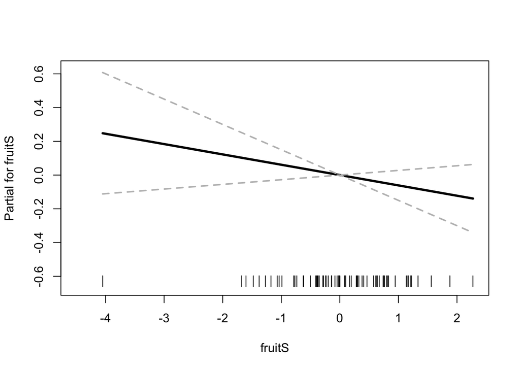

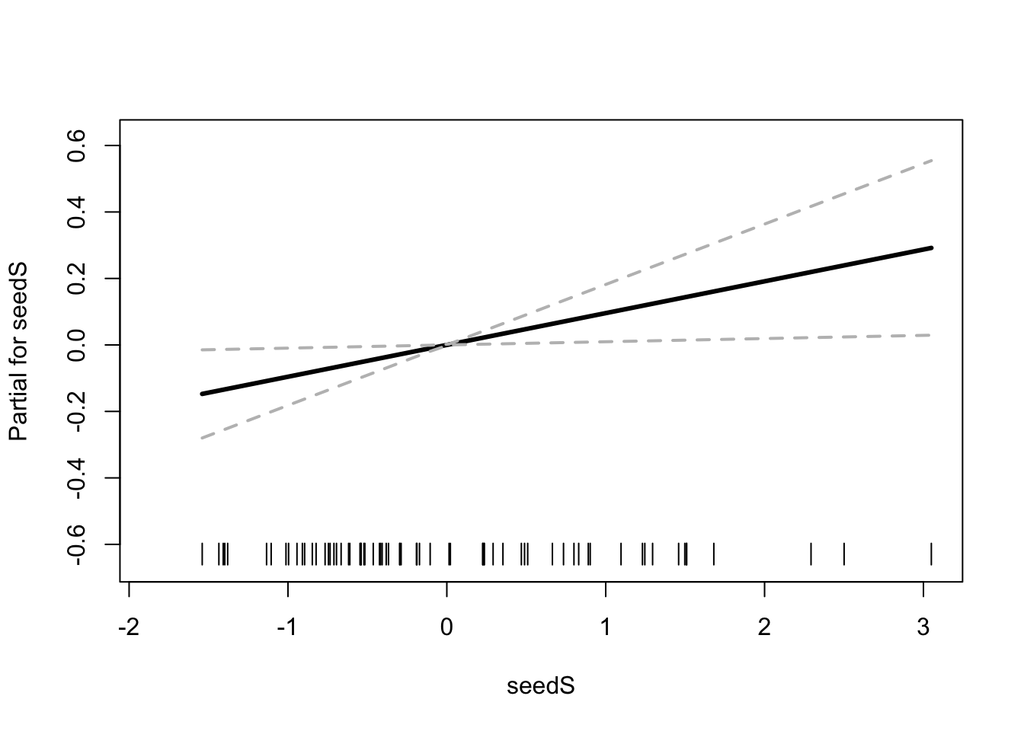

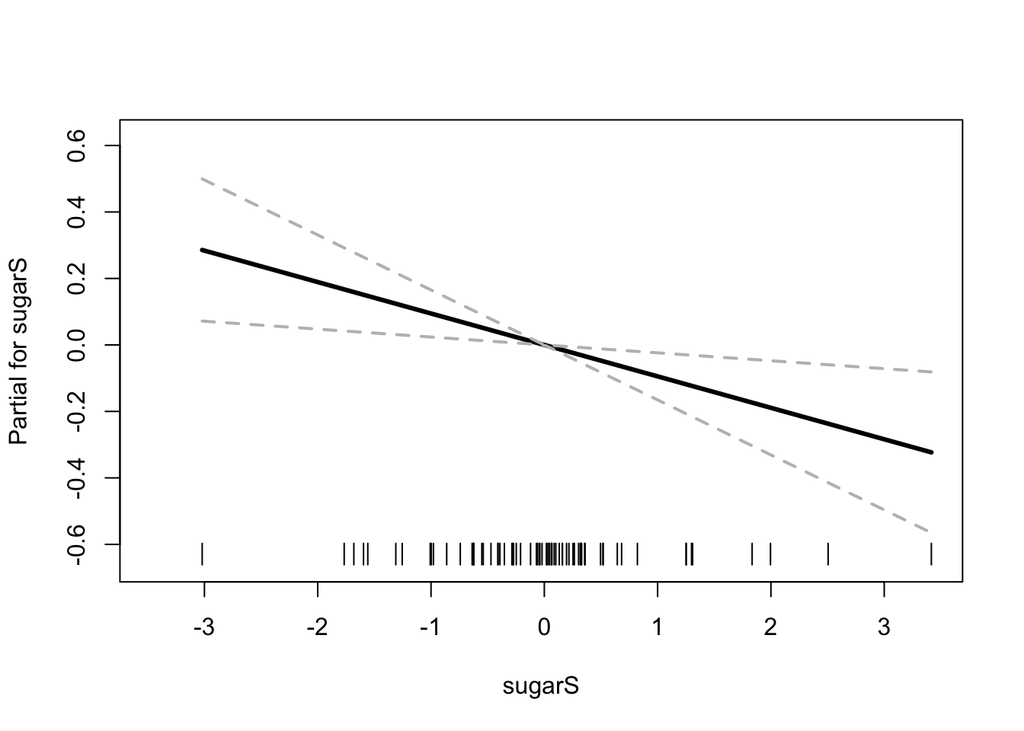

### Spatial model

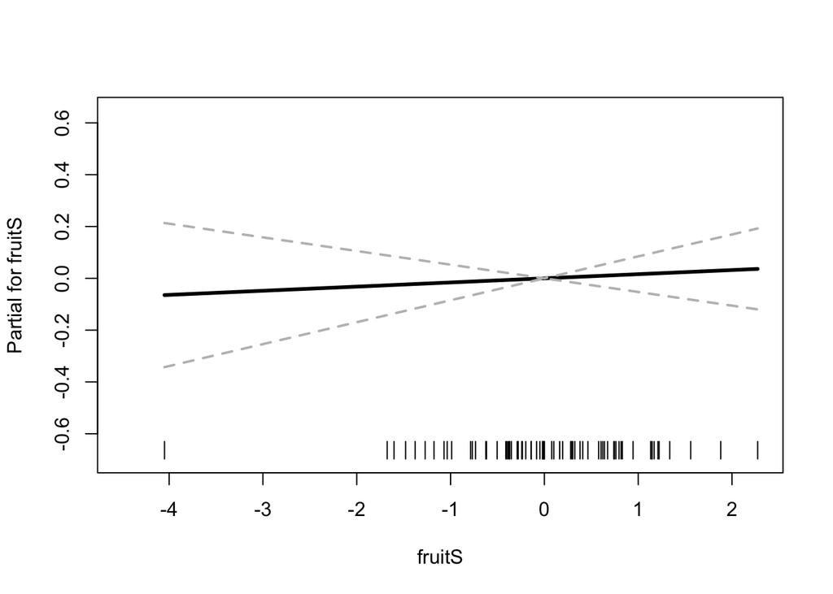

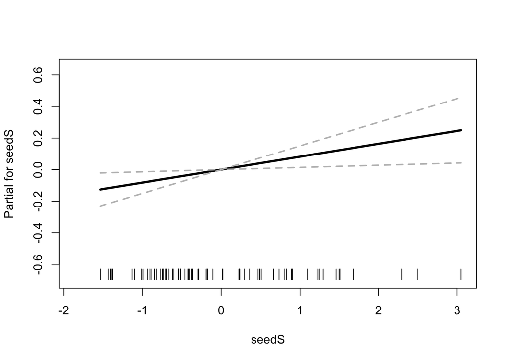

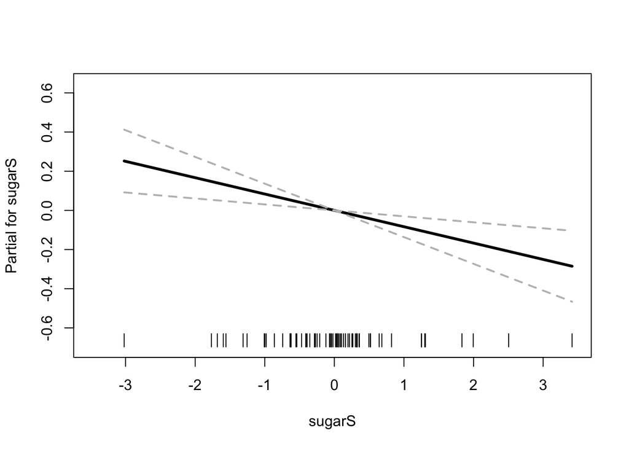

### Genetic model

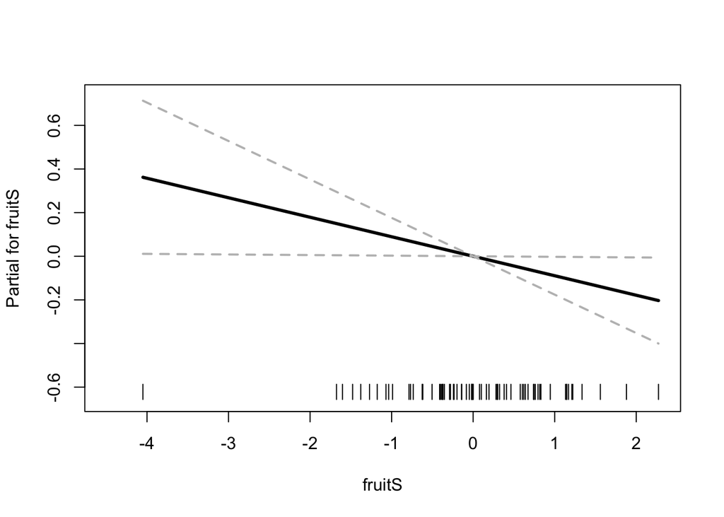

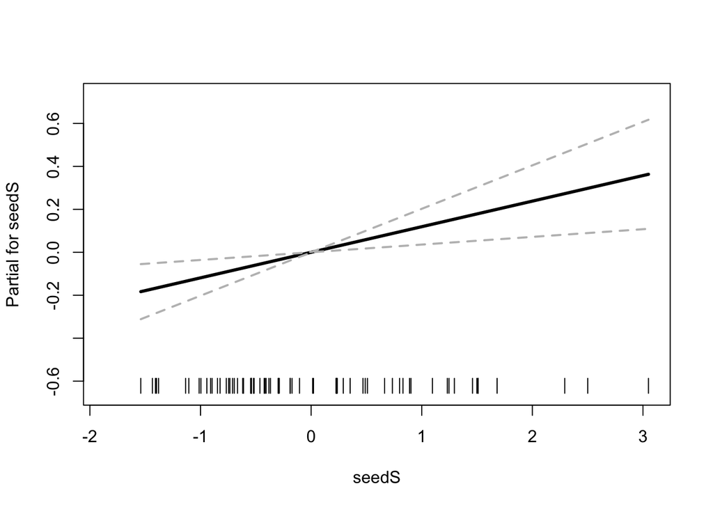

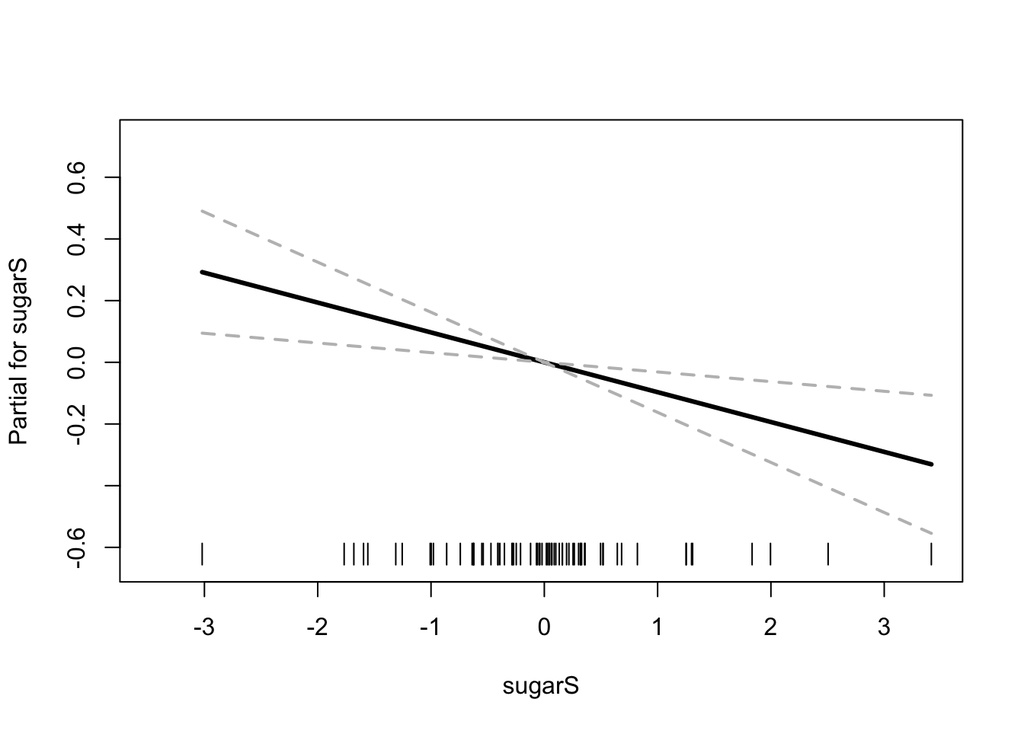

### Spatial + genetic model

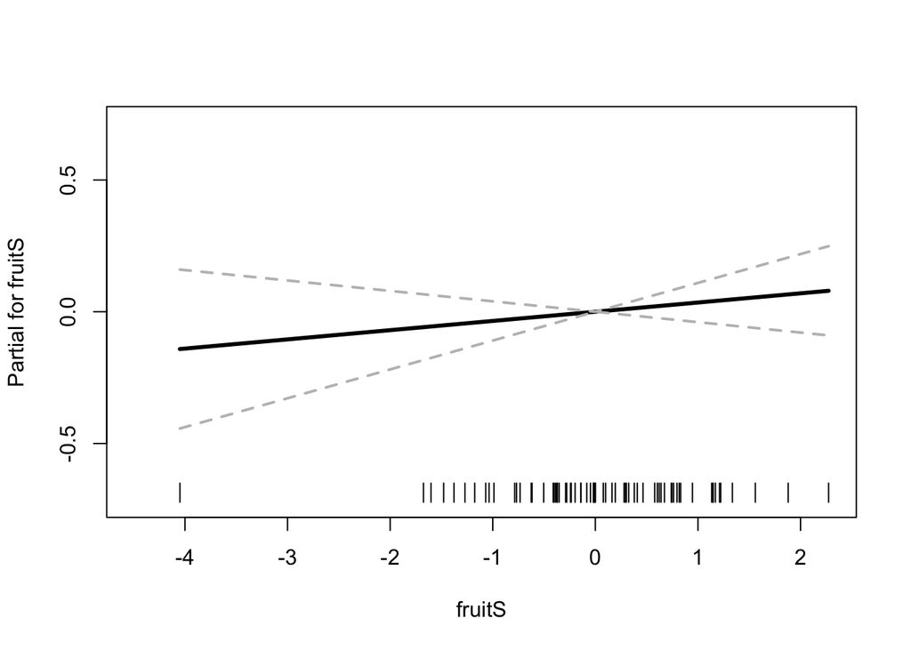

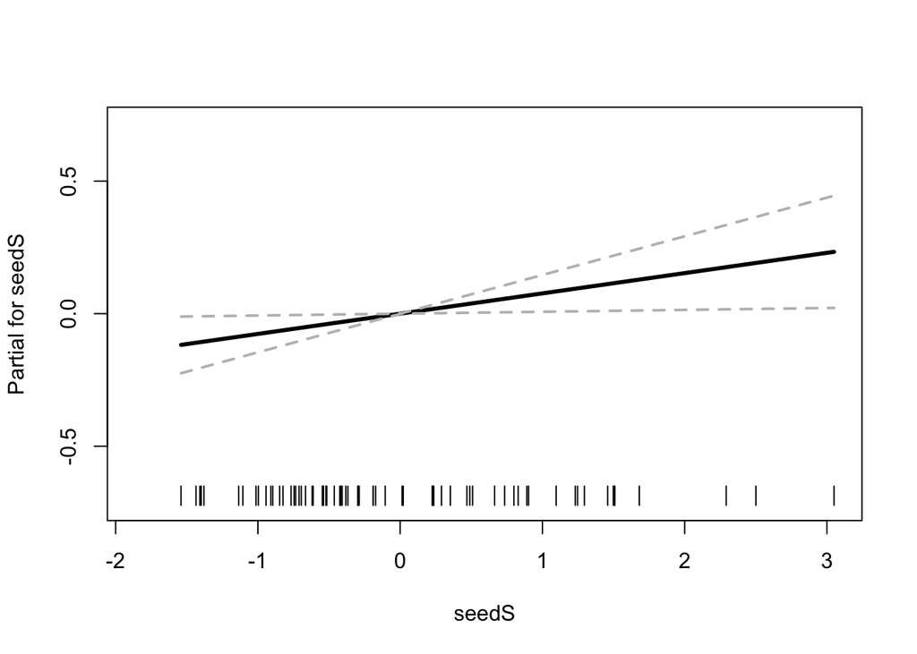

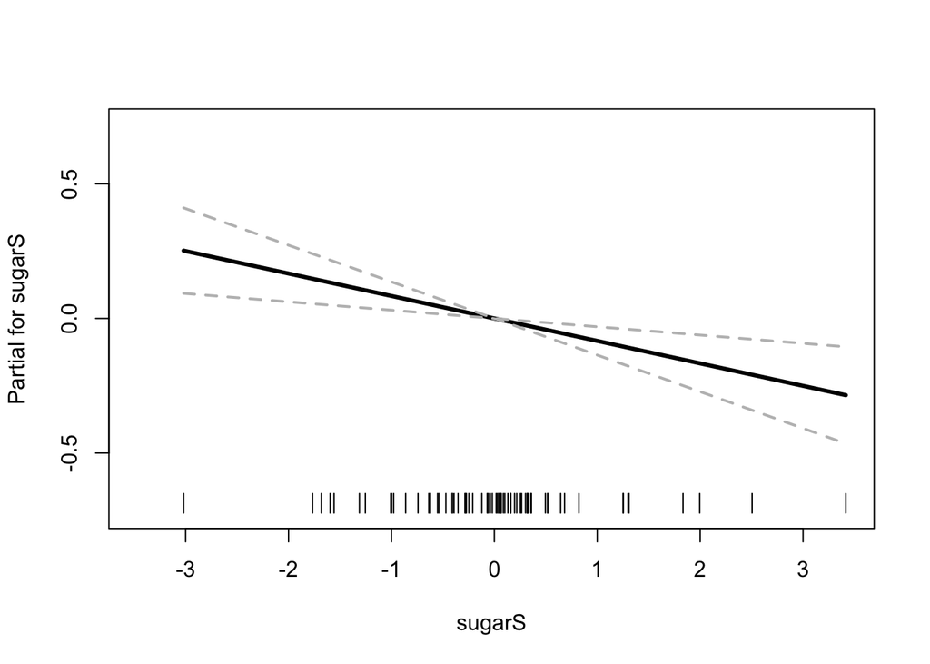

**Note:** These plots can be found in the *termplot* folder.

## GAM check

We will use the `gam.check` function to see how good (or bad) our models are bot overfitted (i.e., too many parameters for the data) and how residuals are behaving.

### Classic model

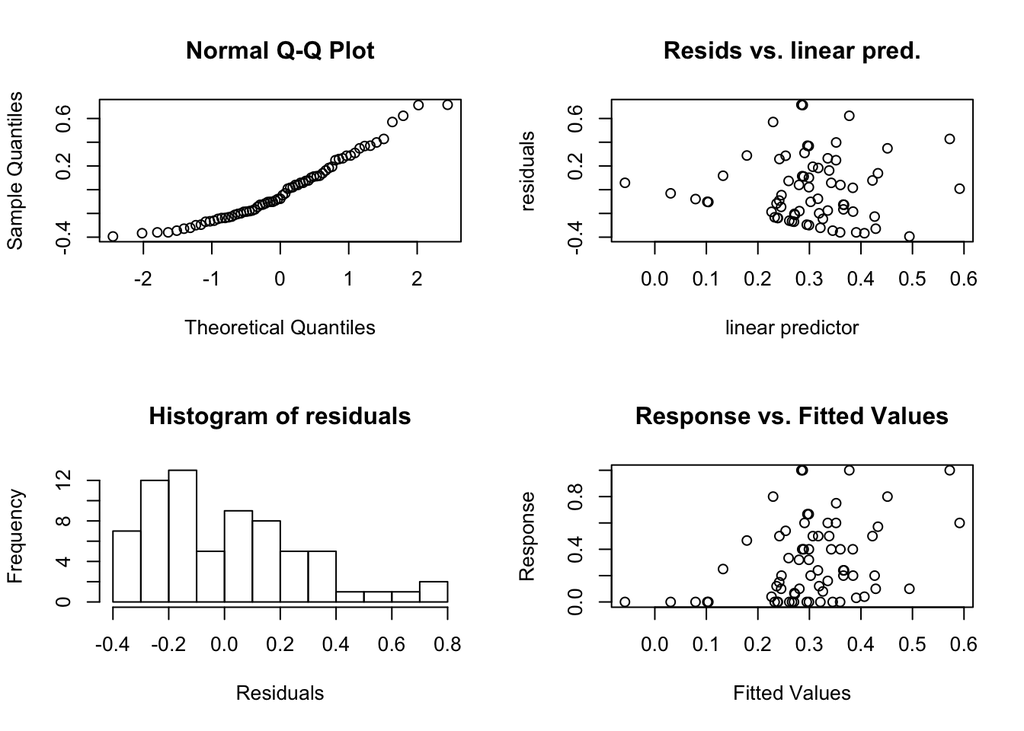

```
##
## Method: GCV   Optimizer: magic
## Model required no smoothing parameter selectionModel rank =  4 / 4
```

### Spatial model

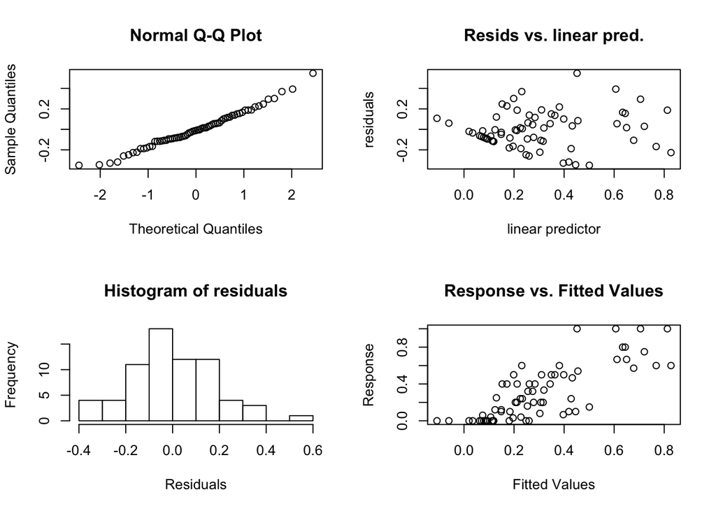

```
##
## Method: GCV   Optimizer: magic
## Smoothing parameter selection converged after 4 iterations.
## The RMS GCV score gradient at convergence was 3.463335e-06 .
## The Hessian was positive definite.
## Model rank =  13 / 13
##
## Basis dimension (k) checking results. Low p-value (k-index<1) may
## indicate that k is too low, especially if edf is close to k'.
##
##          k'  edf k-index p-value
## s(x,y) 9.00 6.84    1.15     0.9
```

### Genetic model

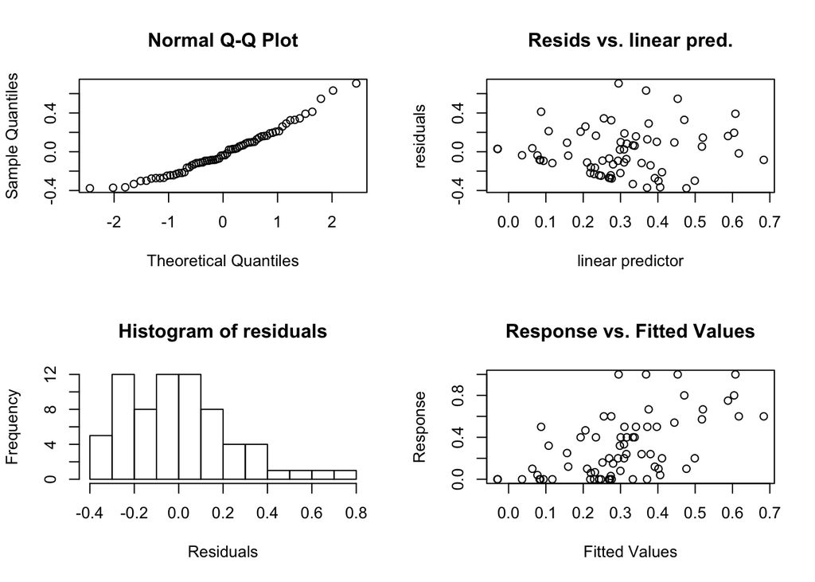

```
##
## Method: GCV   Optimizer: magic
## Smoothing parameter selection converged after 6 iterations.
## The RMS GCV score gradient at convergence was 1.49332e-07 .
## The Hessian was positive definite.
## Model rank =  10 / 10
##
## Basis dimension (k) checking results. Low p-value (k-index<1) may
## indicate that k is too low, especially if edf is close to k'.
##
##                        k'  edf k-index p-value
## s(mds[, 1],mds[, 2]) 6.00 4.67    0.97    0.32
```

### Spatial + genetic model

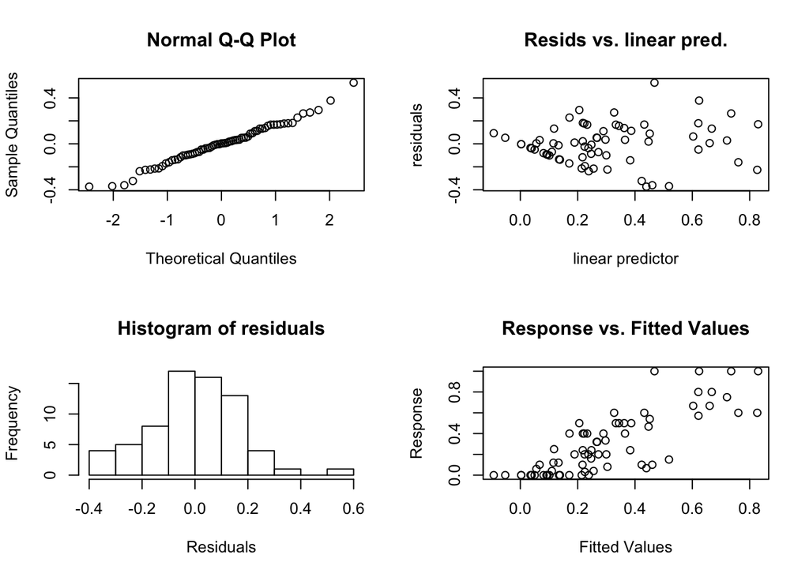

```
##
## Method: GCV   Optimizer: magic
## Smoothing parameter selection converged after 7 iterations.
## The RMS GCV score gradient at convergence was 2.161569e-07 .
## The Hessian was positive definite.
## Model rank =  20 / 20
##
## Basis dimension (k) checking results. Low p-value (k-index<1) may
## indicate that k is too low, especially if edf is close to k'.
##
##                        k'  edf k-index p-value
## s(x,y)               9.00 6.99    1.17    0.92
## s(mds[, 1],mds[, 2]) 7.00 2.51    1.04    0.64
```

## Assessing multicollinearity

To be sure that our results are not influenced by strong multicollinearity, we performed three tests: (1) estimating confidence intervals, (2) estimating the variance inflation factors (VIF), and (3) a `concurvity` analysis (except for the classic model).

**About concurvity:** Concurvity occurs when some smooth term in a model could be approximated by one or more of the other smooth terms in the model. This is often the case when a smooth of space is included in a model, along with smooths of other covariates that also vary more or less smoothly in space. Similarly it tends to be an issue in models including a smooth of time, along with smooths of other time varying covariates.

Concurvity can be viewed as a generalization of co-linearity, and causes similar problems of interpretation. It can also make estimates somewhat unstable (so that they become sensitive to apparently innocuous modelling details, for example).

This routine computes three related indices of concurvity, all bounded between 0 and 1, with 0 indicating no problem, and 1 indicating total lack of identifiability. The three indices are all based on the idea that a smooth term, f, in the model can be decomposed into a part, g, that lies entirely in the space of one or more other terms in the model, and a remainder part that is completely within the term’s own space. If g makes up a large part of f then there is a concurvity problem. The indices used are all based on the square of ||g||/||f||, that is the ratio of the squared Euclidean norms of the vectors of f and g evaluated at the observed covariate values.

### Classic model

```
## # A tibble: 4 x 6
##   term        Estimate `Std. Error` Statistic   `2.5%` `97.5%`
##   <chr>          <dbl>        <dbl>     <dbl>    <dbl>   <dbl>
## 1 (Intercept)   0.300        0.0336      8.92  0.233    0.367
## 2 fruitS       -0.0612       0.0444     -1.38 -0.150    0.0275
## 3 seedS         0.0957       0.0430      2.22  0.00973  0.182
## 4 sugarS       -0.0946       0.0354     -2.67 -0.165   -0.0239
```

```
## # A tibble: 3 x 2
##   variable   vif
##   <chr>    <dbl>
## 1 fruitS    1.64
## 2 seedS     1.64
## 3 sugarS    1.06
```

### Spatial model

```
## # A tibble: 4 x 6
##   term        Estimate `Std. Error` Statistic  `2.5%` `97.5%`
##   <chr>          <dbl>        <dbl>     <dbl>   <dbl>   <dbl>
## 1 (Intercept)   0.298        0.0235    12.7    0.251   0.345
## 2 fruitS        0.0160       0.0343     0.465 -0.0528  0.0847
## 3 seedS         0.0819       0.0341     2.40   0.0137  0.150
## 4 sugarS       -0.0835       0.0265    -3.15  -0.137  -0.0304
```

```
## # A tibble: 3 x 2
##   variable   vif
##   <chr>    <dbl>
## 1 fruitS    2.00
## 2 seedS     2.10
## 3 sugarS    1.22
```

```
##                 para    s(x,y)
## worst    0.002070851 0.3207236
## observed 0.002070851 0.1146336
## estimate 0.002070851 0.1241656
```

### Genetic model

```
## # A tibble: 4 x 6
##   term        Estimate `Std. Error` Statistic  `2.5%`  `97.5%`
##   <chr>          <dbl>        <dbl>     <dbl>   <dbl>    <dbl>
## 1 (Intercept)   0.301        0.0307      9.80  0.240   0.362
## 2 fruitS       -0.0894       0.0433     -2.06 -0.176  -0.00271
## 3 seedS         0.119        0.0416      2.86  0.0358  0.202
## 4 sugarS       -0.0968       0.0328     -2.96 -0.162  -0.0313
```

```
## # A tibble: 3 x 2
##   variable   vif
##   <chr>    <dbl>
## 1 fruitS    1.87
## 2 seedS     1.84
## 3 sugarS    1.09
```

```
##                 para s(mds[, 1],mds[, 2])
## worst    0.001826967           0.15242686
## observed 0.001826967           0.04091103
## estimate 0.001826967           0.03681151
```

### Spatial + genetic model

```
## # A tibble: 4 x 6
##   term        Estimate `Std. Error` Statistic   `2.5%` `97.5%`
##   <chr>          <dbl>        <dbl>     <dbl>    <dbl>   <dbl>
## 1 (Intercept)   0.298        0.0232    12.9    0.251    0.344
## 2 fruitS        0.0350       0.0372     0.939 -0.0397   0.110
## 3 seedS         0.0765       0.0347     2.20   0.00695  0.146
## 4 sugarS       -0.0834       0.0263    -3.17  -0.136   -0.0308
```

```
## # A tibble: 3 x 2
##   variable   vif
##   <chr>    <dbl>
## 1 fruitS    2.43
## 2 seedS     2.25
## 3 sugarS    1.24
```

```
##                 para    s(x,y) s(mds[, 1],mds[, 2])
## worst    0.002717342 0.6995880            0.6691363
## observed 0.002717342 0.5400792            0.4802573
## estimate 0.002717342 0.3517121            0.3602108
```

## Autocorrelation plots

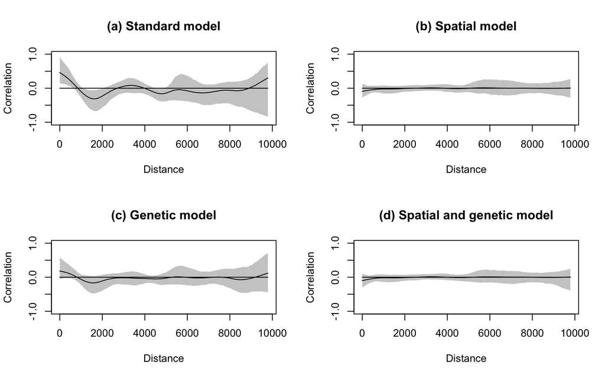

[output not shown]

[output not shown]

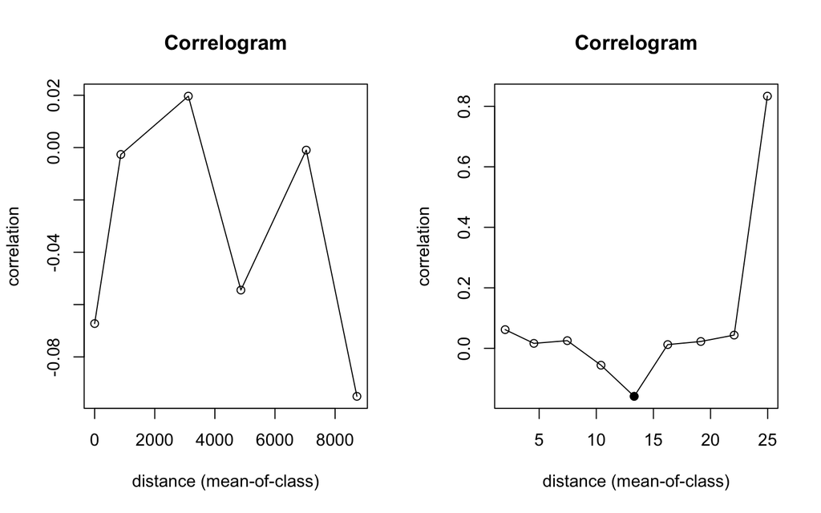

### Mantel partial correlograms

Testing significance using Mantel partial correlograms:

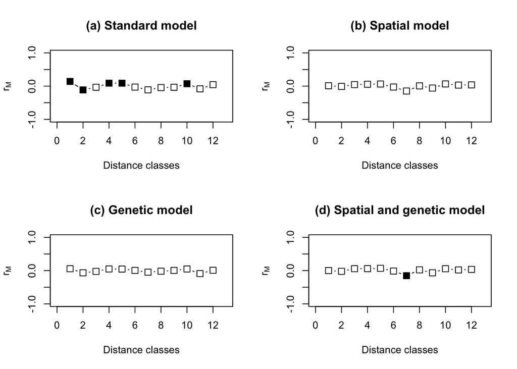

Licensing Creative Commons License

Licensed under a Creative Commons Attribution-ShareAlike 4.0 International License.  
2020 - Francisco E. Fontúrbel